# EXT CSCI E-106 Model Data Class Group Project Template

Charles Atchison

2023-12-05

## I. Introduction: Contextualizing the King County House Price Prediction Model

### Problem Statement and Objective

In the vibrant and diverse King County real estate market, including Seattle’s dynamic environment, property prices are shaped by an array of variables. The primary challenge is to construct a predictive model that can accurately estimate house prices within this area. Utilizing a comprehensive dataset that encompasses diverse house attributes, this model aims to decode the complex mechanisms influencing house pricing.

### Purpose of the Model

#### Predictive Accuracy

The model strives to offer precise price predictions for properties in King County by effectively correlating various house features with their market prices. This aspect is crucial in understanding and quantifying how different characteristics impact the value of a property.

#### Analytical Insight

A key goal of the model is to unearth and interpret the multitude of factors that play a significant role in determining house prices within the region. This venture goes beyond mere statistical analysis to provide practical, real-world insights, thereby enriching the understanding of real estate dynamics for all stakeholders.

#### Decision Support

The model is designed to be a powerful asset for a range of users, including real estate agents, prospective buyers, and sellers. By offering accurate price predictions and deep market insights, it aids in making informed and strategic decisions in the property market.

### Scope and Methodology

#### Data Preprocessing and Exploration

Initial data preparation is vital to ensure accuracy in the model. This stage involves cleansing the data, converting data types, and creating dummy variables for categorical features. Following this, an exploratory data analysis (EDA) is conducted to delve into the dataset’s characteristics, examining statistical summaries and relationships between variables.

#### Feature Selection and Model Assumptions

The process involves using statistical techniques like stepwise regression for feature selection and conducting tests like the Variable Inflation Factor (VIF) and Anderson-Darling to check for multicollinearity and normality, respectively. Additionally, diagnostic plots are used for detecting outliers.

#### Model Development and Validation

A range of models are employed and assessed:

**Linear Models:** Including Ordinary Least Squares (OLS) and Weighted Least Squares (WLS).

**Regularization Techniques:** Such as Ridge, Lasso, and Elastic Net to handle multicollinearity.

**Robust Regression:** Utilizing Huber’s method to minimize the influence of outliers.

**Advanced Models:** Exploring alternatives like regression trees, neural networks (NN), or support vector machines (SVM).

#### Model Performance Evaluation

The model’s effectiveness is evaluated using metrics like RMSE and R-squared, across both the training (70%) and testing (30%) data sets, to ensure its reliability and applicability in real-world scenarios.

### Conclusion

This introduction sets the stage for a comprehensive analysis, highlighting the multifaceted approach adopted in this project. From meticulous data preparation to sophisticated modeling, the endeavor is not just to predict house prices accurately but also to provide valuable insights into King County’s real estate market.

## II. Description of the Data and Quality

### Dataset Overview and Detailed Description

The King County house sales dataset is a comprehensive collection of 21,613 observations, each representing a unique house sale. The dataset encompasses a variety of features that describe different aspects of the houses sold. Below is a detailed description of each variable in the dataset:

| Variable | Description |
| --- | --- |
| `id` | Unique ID for each home sold (not used as a predictor) |
| `date` | Date of the home sale |
| `price` | Price of each home sold |
| `bedrooms` | Number of bedrooms |
| `bathrooms` | Number of bathrooms, “.5” accounts for a bathroom with a toilet but no shower |
| `sqft_living` | Square footage of the apartment interior living space |
| `sqft_lot` | Square footage of the land space |
| `floors` | Number of floors |
| `waterfront` | A dummy variable for whether the apartment was overlooking the waterfront or not |
| `view` | An index from 0 to 4 of how good the view of the property was |
| `condition` | An index from 1 to 5 on the condition of the apartment |
| `grade` | An index from 1 to 13 about building construction and design quality |
| `sqft_above` | The square footage of the interior housing space above ground level |
| `sqft_basement` | The square footage of the interior housing space below ground level |
| `yr_built` | The year the house was initially built |
| `yr_renovated` | The year of the house’s last renovation |
| `zipcode` | The zipcode area the house is in |
| `lat` | Latitude coordinate |
| `long` | Longitude coordinate |
| `sqft_living15` | The square footage of interior housing living space for the nearest 15 neighbors |
| `sqft_lot15` | The square footage of the land lots of the nearest 15 neighbors |

### Data Quality and Transformation

#### Data Cleaning and Transformation

The dataset’s preparation involved meticulous cleaning and transformation processes to optimize it for accurate predictive analysis. Key steps undertaken include:

```r
# Data Preprocessing and Transformation
set.seed(123)  # Setting a seed for reproducibility
split_index <- sample(1:nrow(df), size = 0.7 * nrow(df))
train_df <- df[split_index, ]
test_df <- df[-split_index, ]

# Remove non-numeric characters from the 'price' column and convert it to numeric
train_df$price <- as.numeric(str_replace_all(train_df$price, "[^0-9.]", ""))
test_df$price <- as.numeric(str_replace_all(test_df$price, "[^0-9.]", ""))

# Calculation of Convergence Point: Determine the convergence point for high-value homes
high_value_threshold <- quantile(train_df$price, probs = 0.90, na.rm = TRUE)  # Calculate the high-value threshold
high_value_homes <- train_df[train_df$price >= high_value_threshold, ]  # Select high-value homes
convergence_point <- c(mean(high_value_homes$lat, na.rm = TRUE), mean(high_value_homes$long, na.rm = TRUE))  # Calculate the convergence point

# Data Transformation Function with Distance Binning Option
transform_data <- function(df, convergence_point, linear_model) {
  # Date Transformation: Convert the 'date' column to a Date object if present
  if ("date" %in% colnames(df)) {
    df$date <- as.Date(substr(as.character(df$date), 1, 8), format="%Y%m%d")
    # Date-Time Feature Engineering: Extract various date-related features
    df$year_sold <- lubridate::year(df$date)
    df$month_sold <- lubridate::month(df$date)
    df$day_sold <- lubridate::day(df$date)
    df$season <- factor(lubridate::quarter(df$date), labels = c("Winter", "Spring", "Summer", "Fall"))
    df$week_of_year <- lubridate::week(df$date)
    df$day_of_year <- lubridate::yday(df$date)
  }
  # Creating Dummy Variables: Convert categorical variables into dummy variables
  df <- df %>%
    mutate(zipcode = as.factor(zipcode),
           waterfront = as.factor(waterfront),
           view = as.factor(view),
           condition = as.factor(condition),
           grade = as.character(grade)) %>%
    dummy_cols(select_columns = c('zipcode', 'view', 'condition', 'grade', 'waterfront', 'season'))
  # Remove last dummy variables to avoid multicollinearity
  if (linear_model) {
    df <- df[, !(names(df) %in% c("zipcode_98199", "view_0", "condition_1", "grade_13", "season_Winter", "waterfront_1"))]
  }
  # Haversine Distance Function: Calculate the distance between two points on Earth's surface
  haversine_distance <- function(lat1, long1, lat2, long2) {
    R <- 6371  # Earth radius in kilometers
    delta_lat <- (lat2 - lat1) * pi / 180
    delta_long <- (long2 - long1) * pi / 180
    a <- sin(delta_lat/2)^2 + cos(lat1 * pi / 180) * cos(lat2 * pi / 180) * sin(delta_long/2)^2
    c <- 2 * atan2(sqrt(a), sqrt(1 - a))
    d <- R * c  # Calculate the haversine distance
    return(d)
  }
  # Calculate Haversine Distance
  df$distance_to_convergence <- mapply(haversine_distance, df$lat, df$long,
                                       MoreArgs = list(lat2 = convergence_point[1], long2 = convergence_point[2]))
  # Remove columns that are no longer needed
  df <- df[, !(names(df) %in% c("id", "date", "zipcode", "view", "condition", "grade", "waterfront", "season"))]
  return(df)
}
# Applying the transformation function to training and test sets
train_df_linear <- transform_data(train_df, convergence_point, linear_model = TRUE)  # Transform the training data for linear models
test_df_linear <- transform_data(test_df, convergence_point, linear_model = TRUE)    # Transform the test data for linear models
train_df_non_linear <- transform_data(train_df, convergence_point, linear_model = FALSE)  # Transform the training data
test_df_non_linear <- transform_data(test_df, convergence_point, linear_model = FALSE)    # Transform the test data

# Set this to TRUE to update all the json model_parameters that are stored the JSON
# Check if the update_model_parameters is TRUE or not
update_model_parameters <- FALSE

# This updates the json with the parameters that were obtained from the intensive process of running
update_model_json <- function(model_name, features, filepath) {
  model_params <- if (file.exists(filepath)) {
                    fromJSON(filepath)
                  } else {
                    list()
                  }
  model_params[[model_name]] <- features
  write_json(model_params, filepath)
}

# # Save the transformed data as CSV files in the current directory
# write.csv(train_df_linear, "train_df_linear.csv", row.names = FALSE)
# write.csv(test_df_linear, "test_df_linear.csv", row.names = FALSE)
# write.csv(train_df_non_linear, "train_df_non_linear.csv", row.names = FALSE)
# write.csv(test_df_non_linear, "test_df_non_linear.csv", row.names = FALSE)
```

#### Training Data Header

| price | bedrooms | bathrooms | sqft_living | sqft_lot | floors | sqft_above | sqft_basement | yr_built | yr_renovated | lat | long | sqft_living15 | sqft_lot15 | year_sold | month_sold | day_sold | week_of_year | day_of_year | zipcode_98001 | zipcode_98002 | zipcode_98003 | zipcode_98004 | zipcode_98005 | zipcode_98006 | zipcode_98007 | zipcode_98008 | zipcode_98010 | zipcode_98011 | zipcode_98014 | … |
| --- | --- | --- | --- | --- | --- | --- | --- | --- | --- | --- | --- | --- | --- | --- | --- | --- | --- | --- | --- | --- | --- | --- | --- | --- | --- | --- | --- | --- | --- | --- |
| 475000 | 4 | 2.50 | 2040 | 16200 | 2.0 | 2040 | 0 | 1997 | 0 | 47.7366 | -121.958 | 2530 | 15389 | 2015 | 3 | 7 | 10 | 66 | 0 | 0 | 0 | 0 | 0 | 0 | 0 | 0 | 0 | 0 | 0 | … |
| 316000 | 4 | 1.50 | 2120 | 46173 | 2.0 | 2120 | 0 | 1974 | 0 | 47.6503 | -121.968 | 2000 | 46173 | 2015 | 5 | 8 | 19 | 128 | 0 | 0 | 0 | 0 | 0 | 0 | 0 | 0 | 0 | 0 | 0 | … |
| 802000 | 4 | 2.25 | 2130 | 8734 | 2.0 | 2130 | 0 | 1961 | 0 | 47.5672 | -122.161 | 2550 | 8800 | 2014 | 9 | 4 | 36 | 247 | 0 | 0 | 0 | 0 | 0 | 1 | 0 | 0 | 0 | 0 | 0 | … |
| 905000 | 4 | 2.50 | 3330 | 9557 | 2.0 | 3330 | 0 | 1995 | 0 | 47.5526 | -122.102 | 3360 | 9755 | 2015 | 3 | 25 | 12 | 84 | 0 | 0 | 0 | 0 | 0 | 1 | 0 | 0 | 0 | 0 | 0 | … |
| 700000 | 4 | 2.25 | 2440 | 9450 | 1.5 | 2440 | 0 | 1947 | 2014 | 47.7061 | -122.307 | 1720 | 7503 | 2014 | 10 | 30 | 44 | 303 | 0 | 0 | 0 | 0 | 0 | 0 | 0 | 0 | 0 | 0 | 0 | … |
| 178500 | 3 | 1.00 | 900 | 10511 | 1.0 | 900 | 0 | 1961 | 0 | 47.2883 | -122.272 | 1460 | 10643 | 2015 | 2 | 12 | 7 | 43 | 1 | 0 | 0 | 0 | 0 | 0 | 0 | 0 | 0 | 0 | 0 | … |

### Statistical Analysis and Correlation

#### Exploratory Data Analysis (EDA)

The exploratory data analysis (EDA) conducted on the King County house sales dataset is an in-depth exploration aimed at uncovering patterns, anomalies, and relationships within the data. This comprehensive EDA includes a variety of analyses to gain a holistic understanding of the dataset’s characteristics.

1. **Distribution Analysis of Continuous Variables**:
   - This analysis focuses on continuous variables like `price`, `sqft_living`, `sqft_lot`, and others. Key aspects include examining their distributions, identifying potential outliers, and understanding their range and central tendencies.
   - Histograms and box plots are used to visualize these distributions, which can reveal skewness, kurtosis, and other distributional characteristics important for model assumptions.
2. **Categorical Variable Analysis**:
   - The distribution and count of categorical variables such as `bedrooms`, `bathrooms`, `floors`, `waterfront`, `view`, `condition`, and `grade` are analyzed.
   - Bar plots and frequency tables help in understanding the prevalence of different categories and their potential impact on house prices.
3. **Correlation Analysis**:
   - Understanding how continuous variables correlate with each other and, more importantly, with the target variable `price`.
   - A correlation matrix and corresponding heat map provide a visual and quantitative view of these relationships, highlighting variables that might have a strong positive or negative relationship with house prices.
4. **Temporal Trends Analysis**:
   - Analyzing the influence of time-related features such as `year_sold`, `month_sold`, and `season` on house prices.
   - Time series plots and seasonal decomposition can reveal trends, seasonality, and cyclical patterns in house prices.
5. **Geographical Influence Analysis**:
   - Investigating the spatial aspect by analyzing the `distance_to_convergence` variable.
   - Scatter plots or spatial heat maps can illustrate if proximity to the high-value convergence point influences house prices.

### Continuous Variable Analysis

This analysis focuses on continuous variables like `price`, `sqft_living`, `sqft_lot`, and others. Key aspects include examining their distributions, identifying potential outliers, and understanding their range and central tendencies.

#### Price vs. Square Footage of Living Space

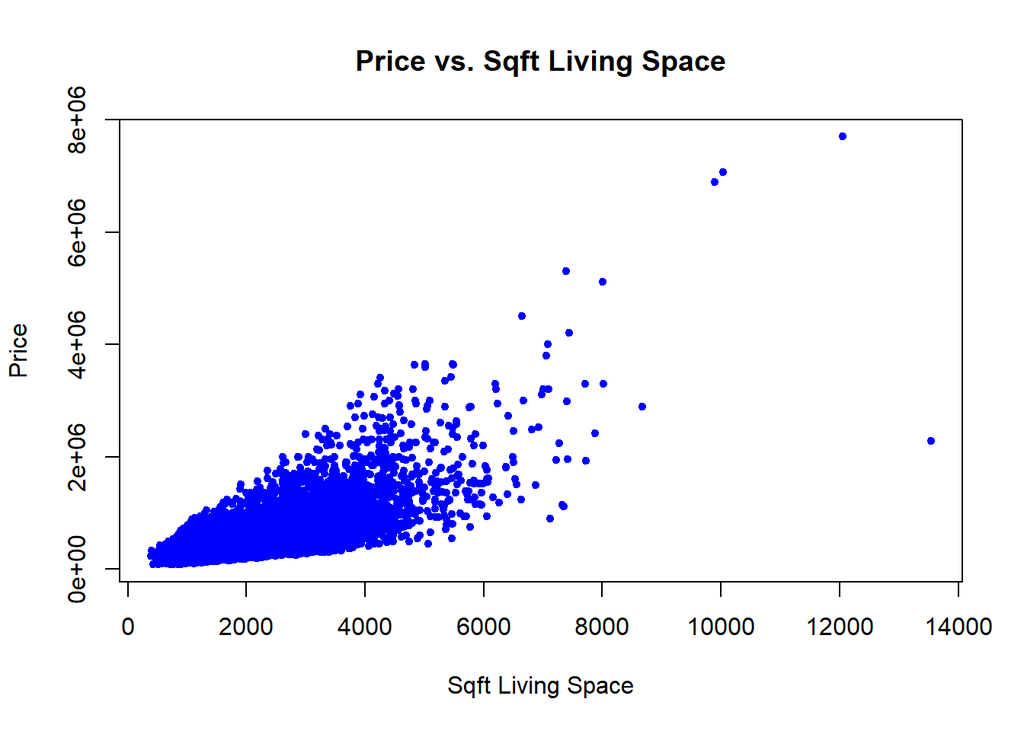

In the scatter plot above, we compare the `price` of homes against their `sqft_living` (square footage of interior living space). This visualization allows us to explore the relationship between these two variables.

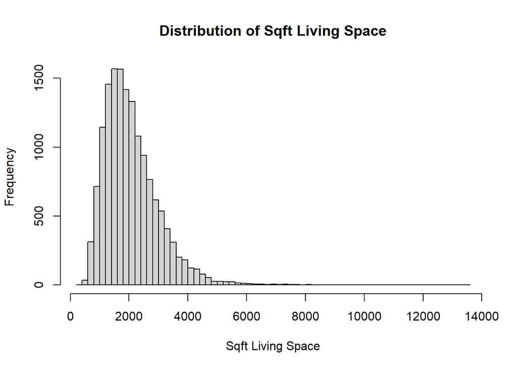

The histogram above displays the distribution of `sqft_living`. It reveals that the variable is right-skewed, with most homes having smaller living spaces and relatively fewer very large living spaces.

#### Price vs. Square Footage of Lot

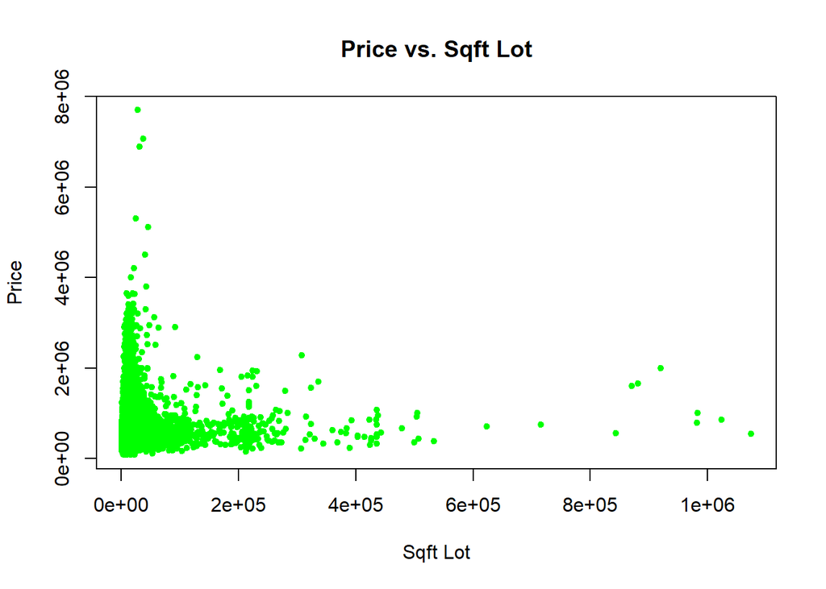

The scatter plot above compares `price` against `sqft_lot` (square footage of land space). It helps us understand if there’s any relationship between the size of the lot and the sale price.

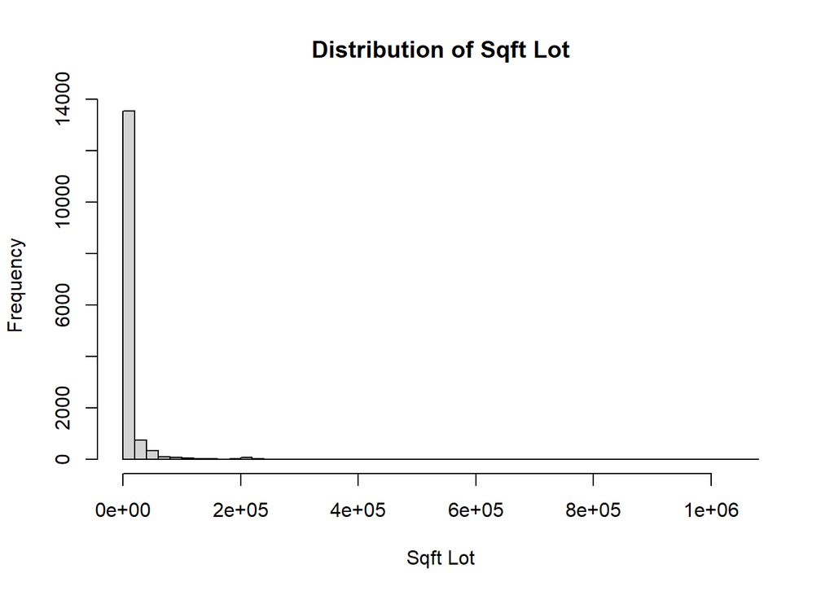

The histogram above visualizes the distribution of `sqft_lot`. Similar to `sqft_living`, this variable is right-skewed, with most homes having smaller lot sizes and relatively fewer very large lots.

#### Price vs. Square Footage Above Ground

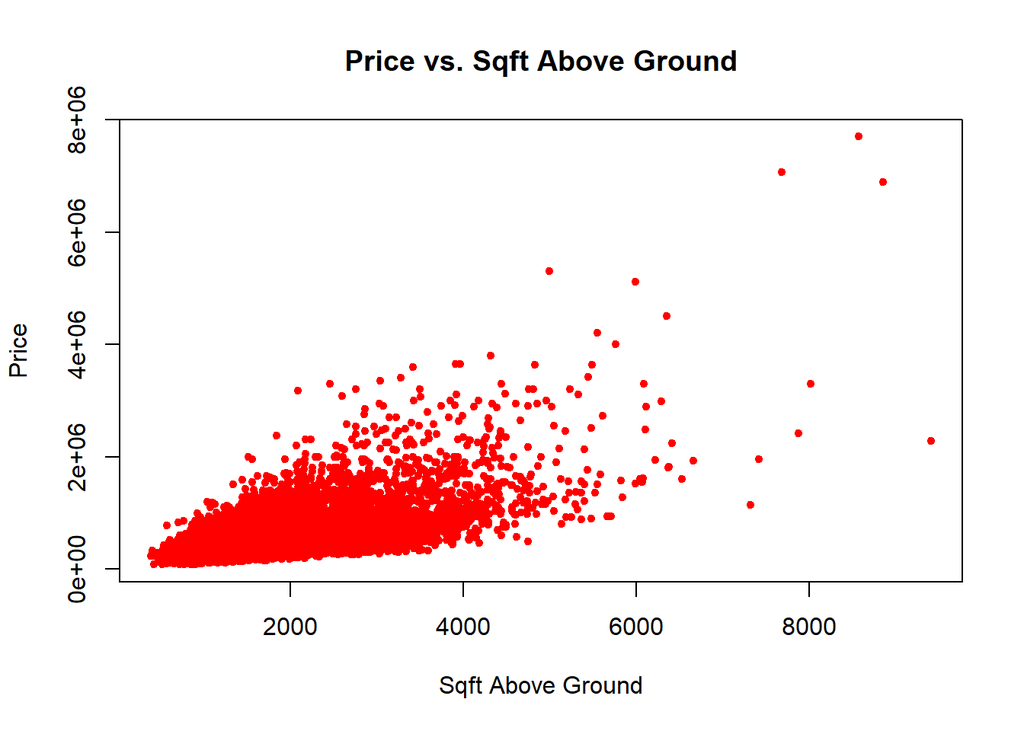

In the scatter plot above, we compare `price` against `sqft_above` (square footage of the interior housing space above ground level). This analysis helps us explore the impact of above-ground living space on home prices.

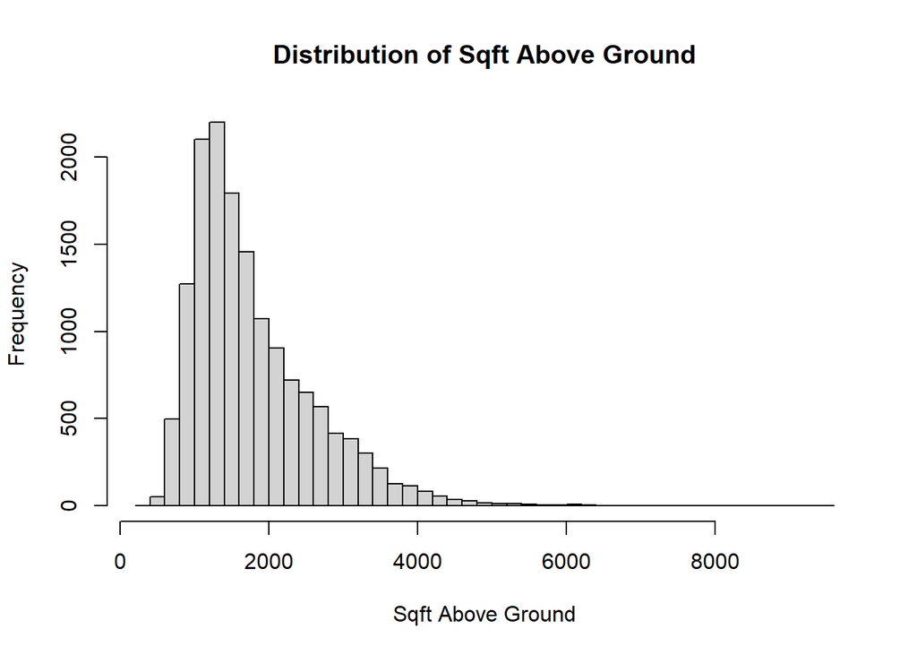

The histogram above shows the distribution of `sqft_above`. It suggests that most homes have similar above-ground square footage, with relatively fewer having significantly larger or smaller above-ground spaces.

#### Price vs. Square Footage of Basement

Excluding homes that do not have a basement.

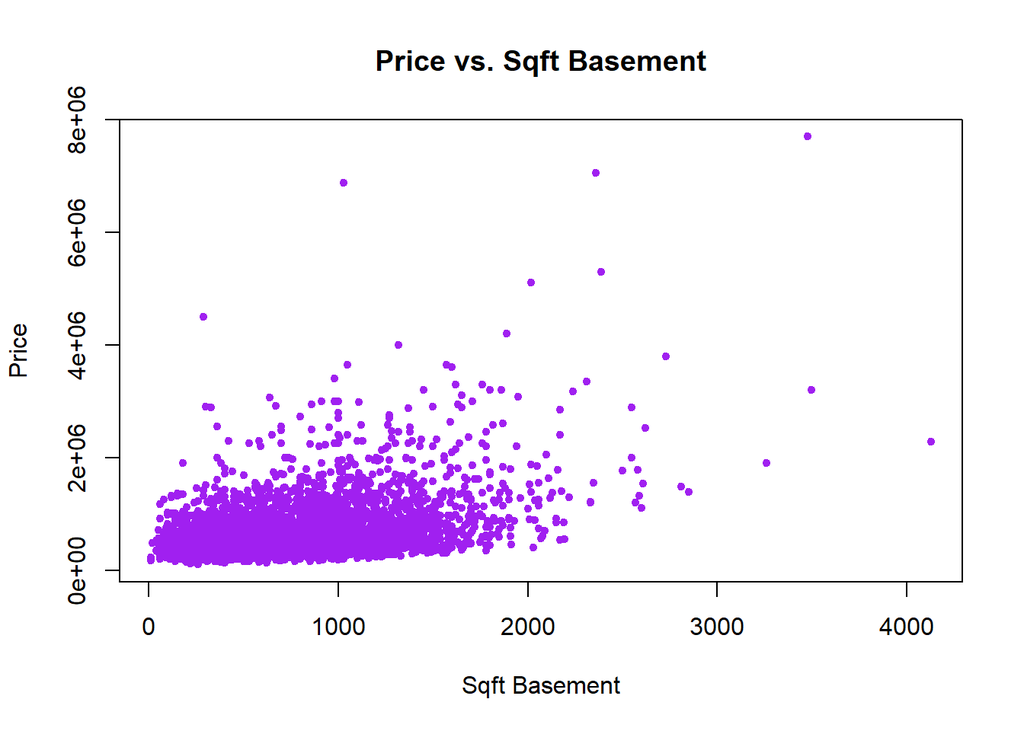

The scatter plot above compares `price` against `sqft_basement` (square footage of the interior housing space below ground level). This visualization helps us understand if the presence and size of a basement influence home prices.

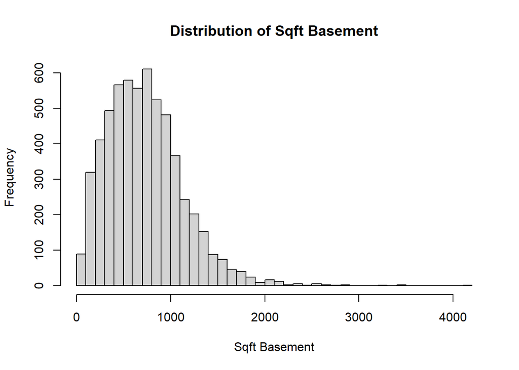

#### Price vs. Year Built

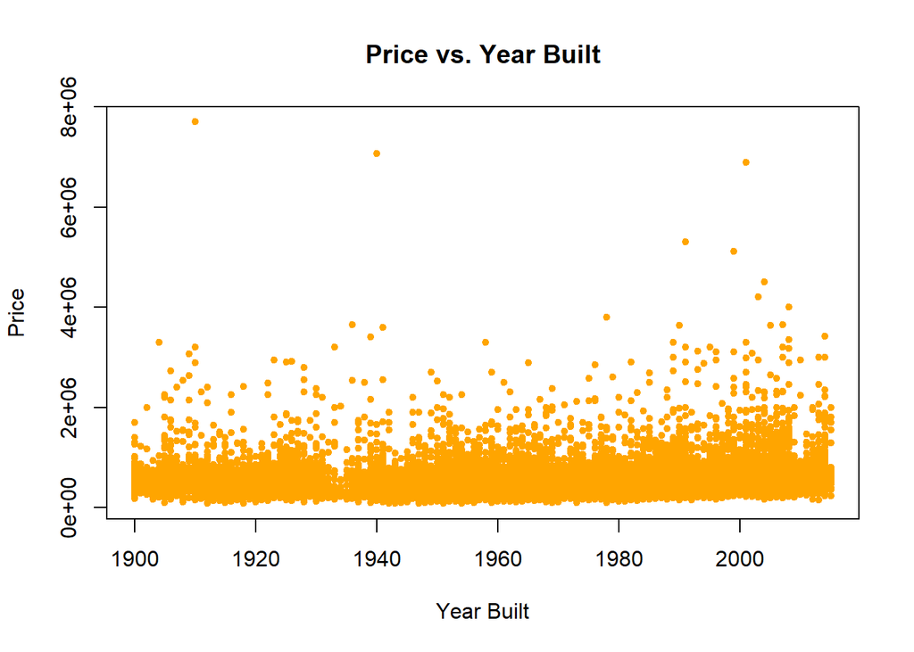

The scatter plot above compares `price` against the year when homes were initially built (`yr_built`). This analysis helps us understand how the age of a home relates to its sale price.

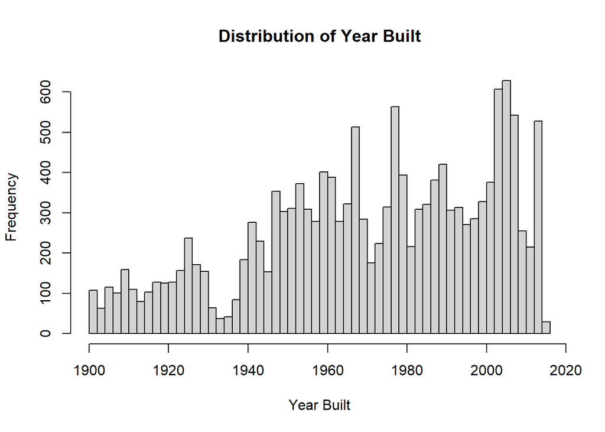

The histogram above displays the distribution of `yr_built`. It provides insights into the distribution of home ages in the dataset.

#### Price vs. Year of Last Renovation

Excluding homes that did not have a documented renovation.

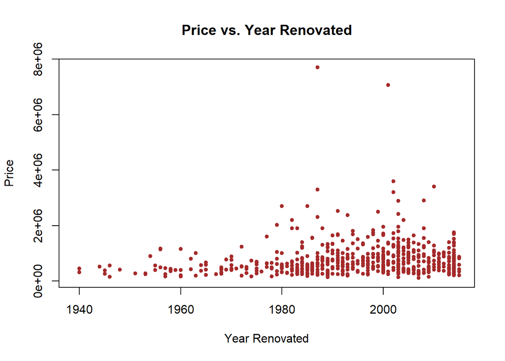

In the scatter plot above, we compare `price` against the year of the last renovation (`yr_renovated`). This analysis helps us understand whether recent renovations impact home prices.

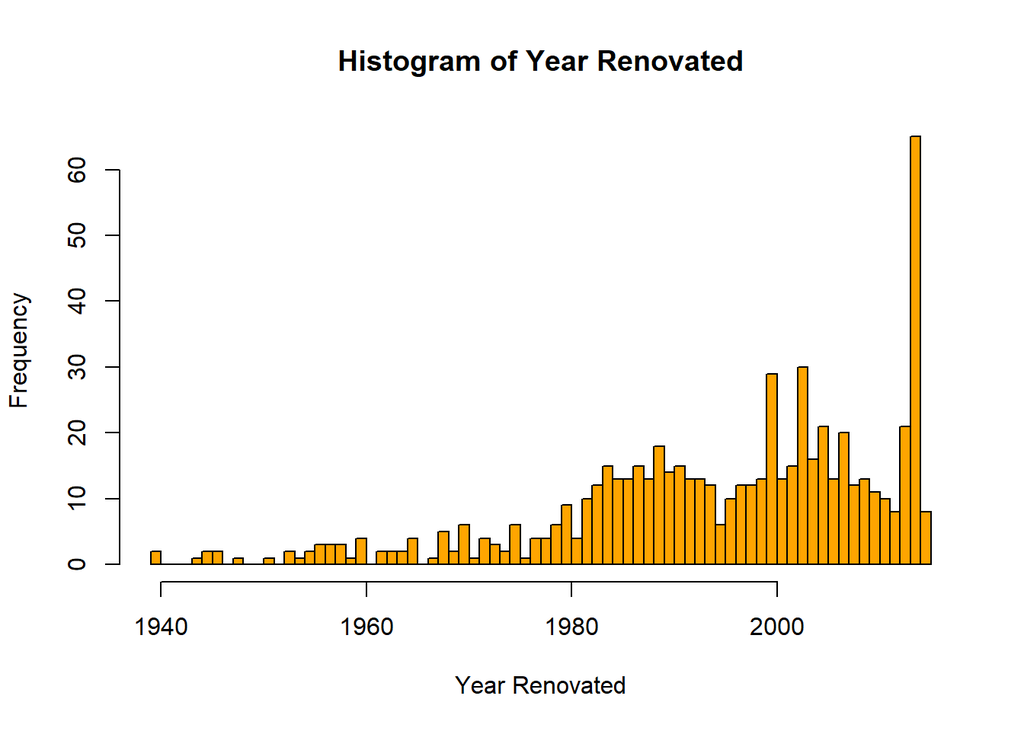

The histogram above visualizes the distribution of `yr_renovated`. It provides insights into the distribution of renovation years in the dataset.

#### Price vs. Distance to Convergence

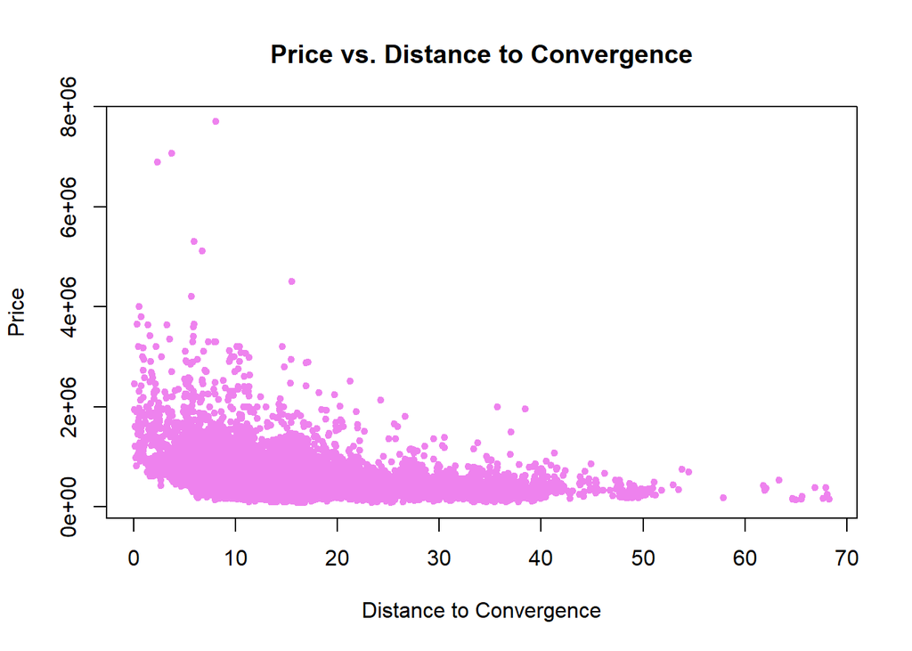

The scatter plot above compares `price` against `distance_to_convergence`. This analysis helps us explore whether the distance to a convergence point impacts home prices.

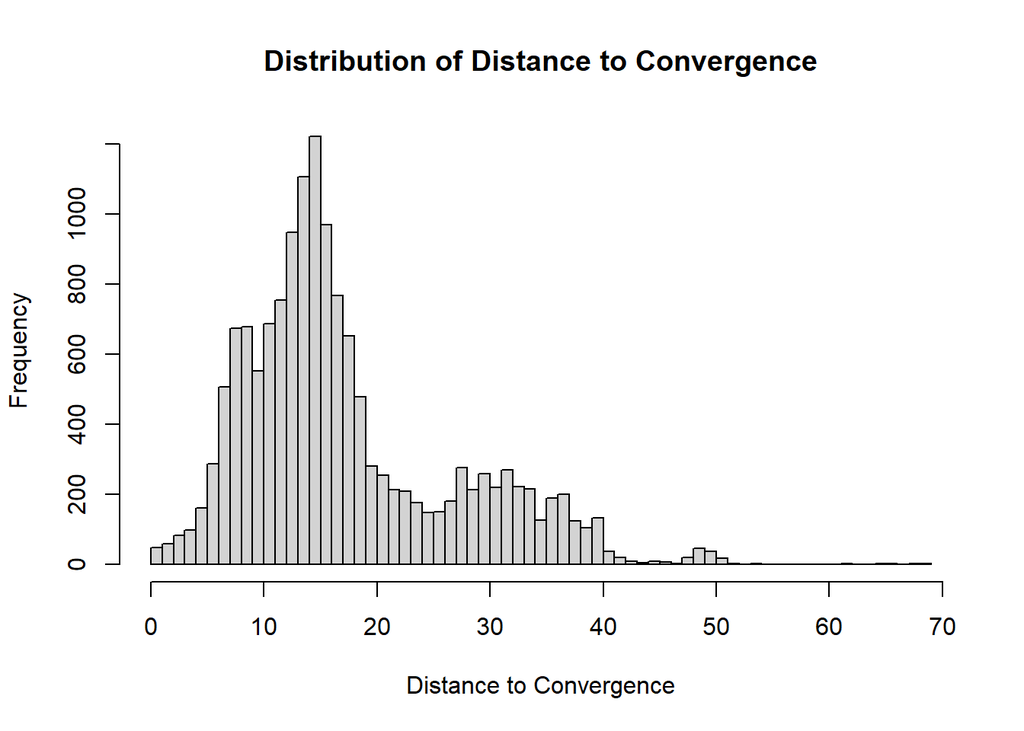

### Categorical Variable Analysis

The distribution and count of categorical variables such as `bedrooms`, `bathrooms`, `floors`, `waterfront`, `view`, `condition`, and `grade` are analyzed.

#### Price vs. Bedrooms

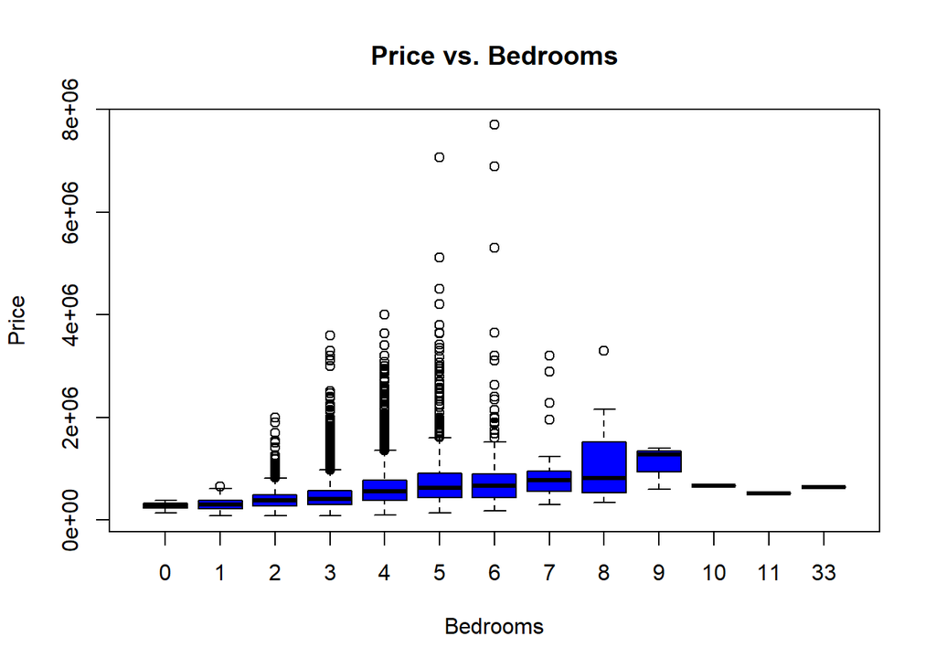

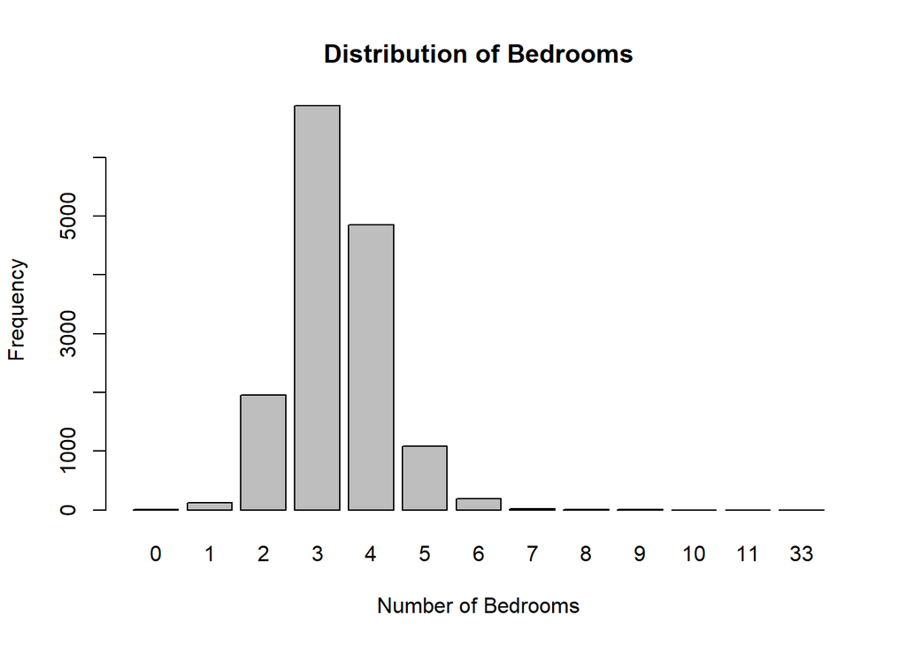

The bar plot above displays the distribution of the `bedrooms` variable, showing the frequency of each bedroom count.

#### Price vs. Bathrooms

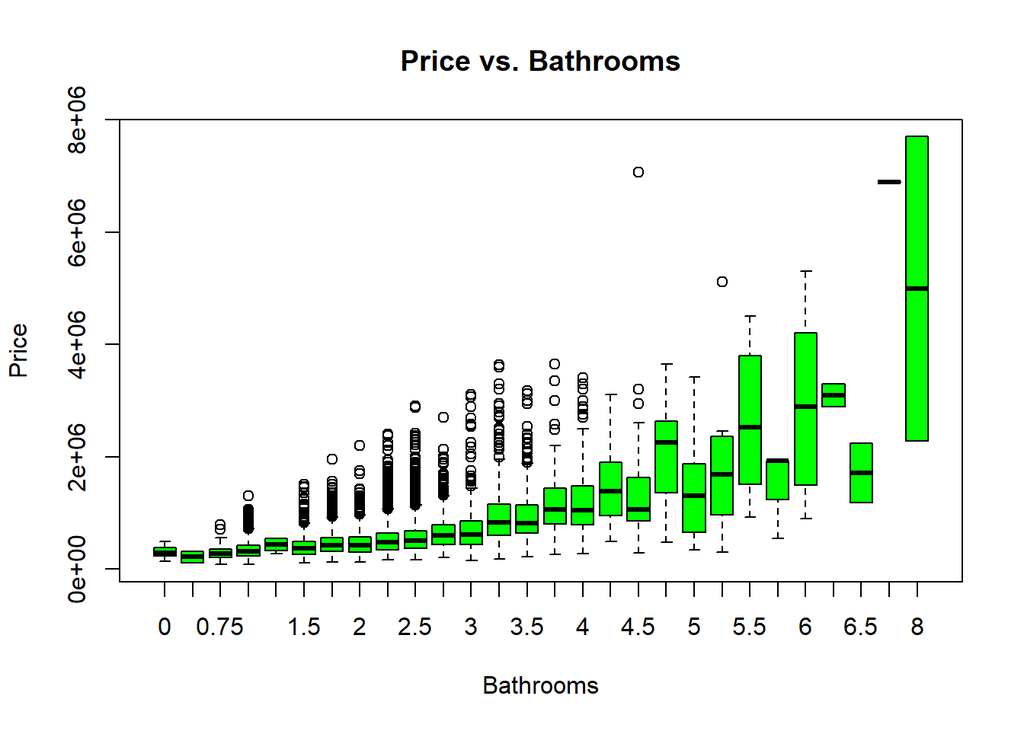

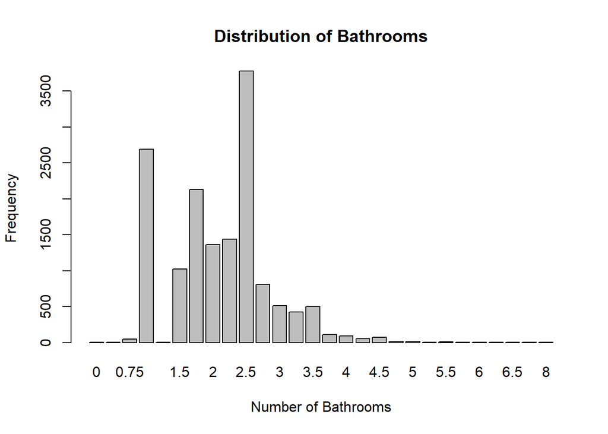

The bar plot above visualizes the distribution of the `bathrooms` variable, showing the frequency of each bathroom count.

#### Price vs. Floors

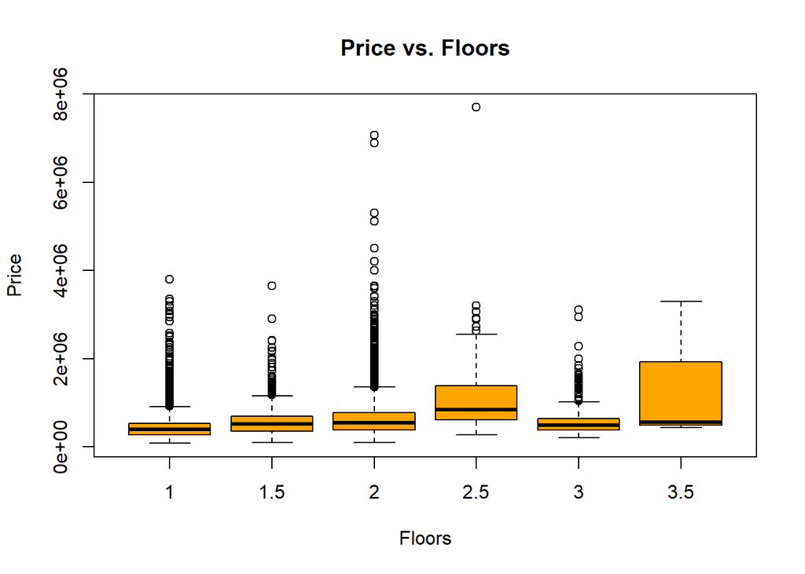

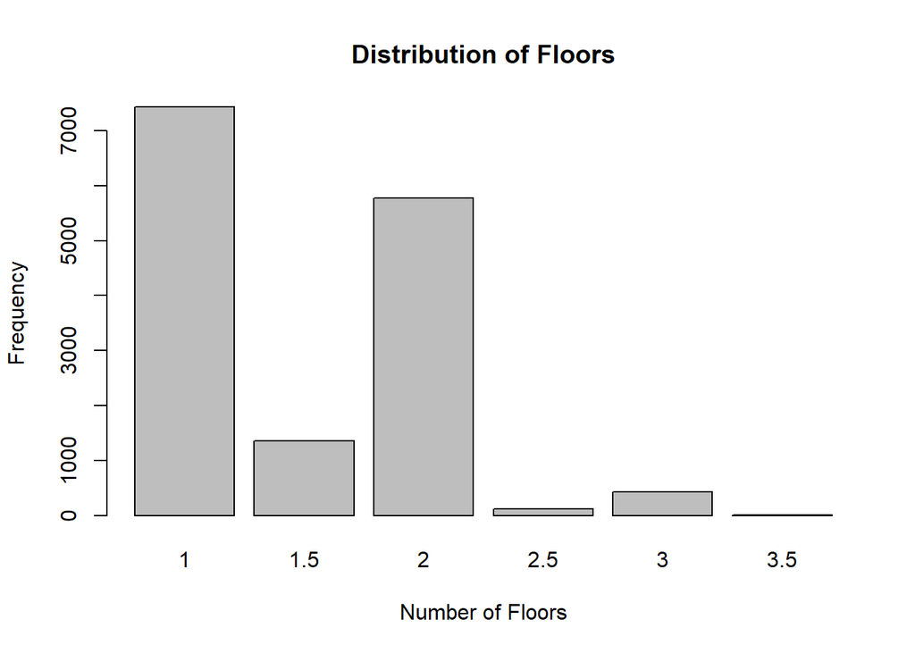

The bar plot above displays the distribution of the `floors` variable, showing the frequency of each floor count.

#### Price vs. Waterfront

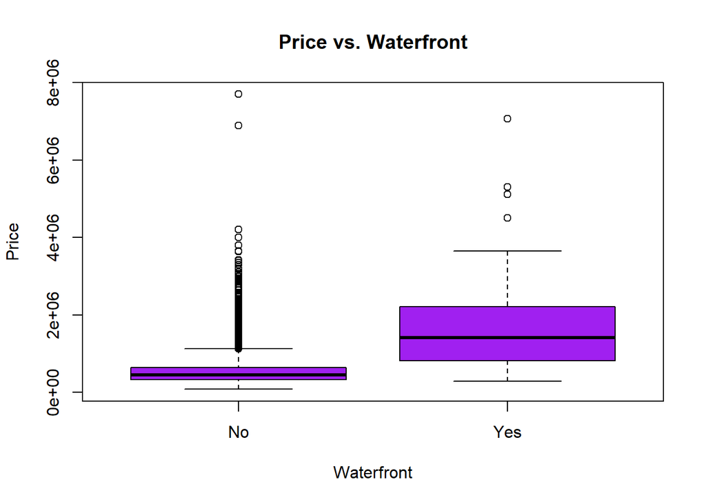

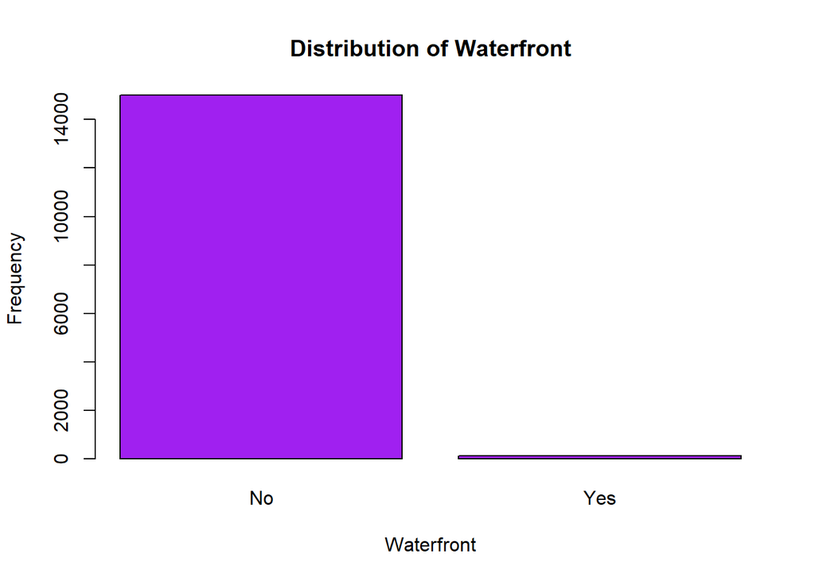

The bar plot above visualizes the distribution of the `waterfront` variable, showing the frequency of waterfront and non-waterfront properties.

#### Price vs. View

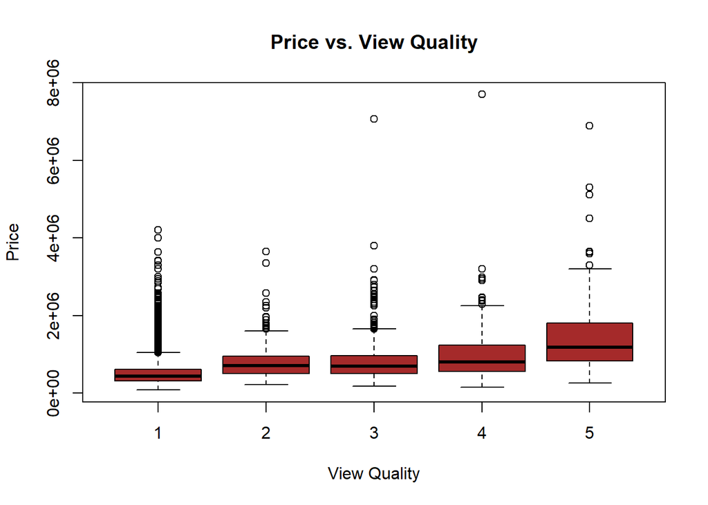

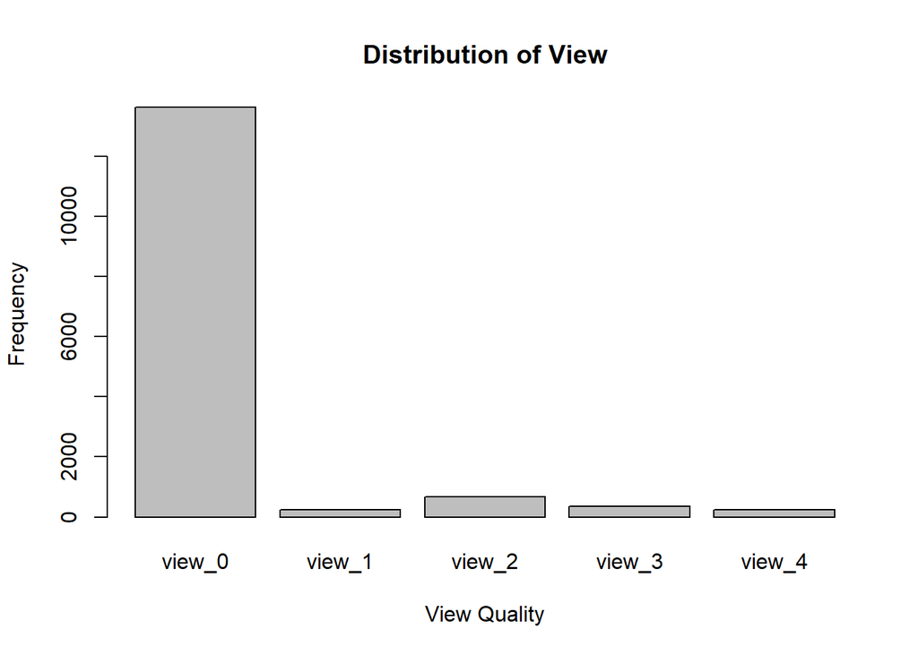

The bar plot above displays the distribution of the `view` variable, showing the frequency of different view quality ratings.

#### Price vs. Condition

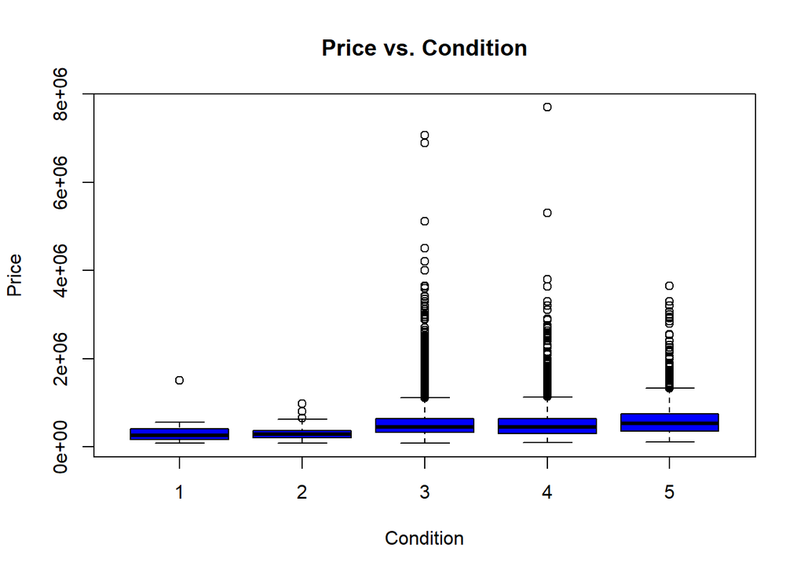

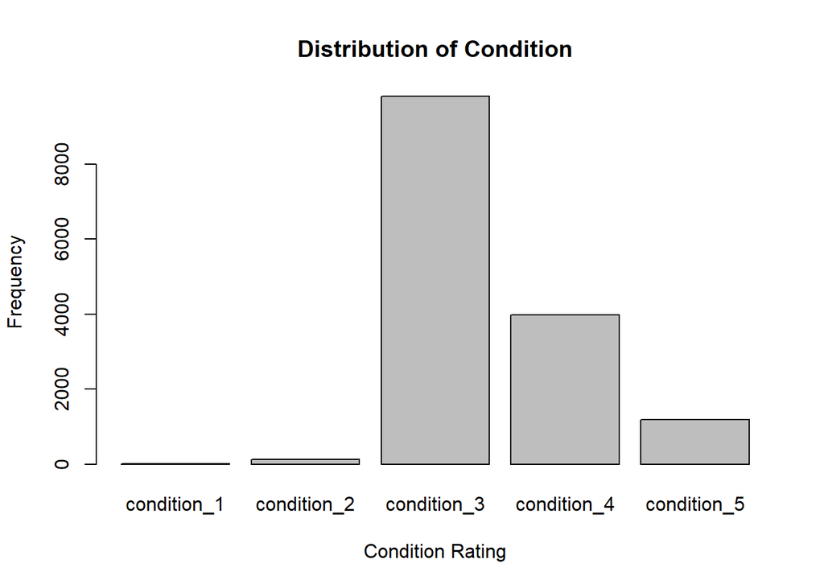

The bar plot above visualizes the distribution of the `condition` variable, showing the frequency of different condition ratings.